# Reproducibility statement

[output not shown]

- MD5 checksum of each uploaded read file was calculated to ensure file integrity

| file | md5sum |
| --- | --- |
| S01_1.raw.fq.gz | 28519953e73888f4fef6e2bb04905b1a |
| S01_2.raw.fq.gz | af53548db05c980f12291e0a936e8c40 |
| S02_1.raw.fq.gz | dbd61c42b07cc1c957303f9906a43f63 |
| S02_2.raw.fq.gz | 6af066515a3b5947836d2aa4d7f32279 |
| S03_1.raw.fq.gz | 762bd8cf153ef6fa49e1dfef2c5d8cf3 |
| S03_2.raw.fq.gz | 089b406548f1e6f1d29d1872090338ab |
| S04_1.raw.fq.gz | 66b1ee67581668312b77c7f1a45d510a |
| S04_2.raw.fq.gz | 4accdfd74fceee18bd0153c4ea12bc2f |
| S05_1.raw.fq.gz | af13e6752646d6d6d551359099568f9d |
| S05_2.raw.fq.gz | 9eda6862ace1f08490c7b6dbd9083127 |
| S06_1.raw.fq.gz | 6090353f2dc6d716816f21b071d31b25 |
| S06_2.raw.fq.gz | cefe3601c531992f2b1e91af59891d51 |
| S07_1.raw.fq.gz | 0ed54a4bcd6793d5ae09793173ad2008 |
| S07_2.raw.fq.gz | 5e053a29e248861759ac6627b8a6e7c4 |
| S08_1.raw.fq.gz | dde2027fd7b1585cc91f631d76ed43a8 |
| S08_2.raw.fq.gz | 5deaf8db573f354bc70fd39f93d74e54 |
| S09_1.raw.fq.gz | 5fe8196ead551e3212e7d44b65e7ba4c |
| S09_2.raw.fq.gz | 2d378d7eab7c724d4af792981c0d38a3 |
| S10_1.raw.fq.gz | 8fc2add788ea05df748f15e5da8de96c |
| S10_2.raw.fq.gz | 575002e2ff412d0cdefee375b158c72b |
| S11_1.raw.fq.gz | 680d57b1eb36357a7bb2c9cb71ab9762 |
| S11_2.raw.fq.gz | 3875b8530396b99d2ea78ebb16719fd3 |
| S12_1.raw.fq.gz | 6d0ebceec13aaa0469bca82167a85300 |
| S12_2.raw.fq.gz | e9058ea5db752f7e7ff736a922599b7e |
| S13_1.raw.fq.gz | 5a73bff61d20354cc57ea561151f49e2 |
| S13_2.raw.fq.gz | 34543bde0e12ab0fda470c5febd4ca10 |
| S14_1.raw.fq.gz | cc77283e40d1477e3914ae8202daf239 |
| S14_2.raw.fq.gz | dcea8fa7e66908766bd14547072b6596 |
| S15_1.raw.fq.gz | a6ea5828f6e22b89d87a911f0baa41cd |
| S15_2.raw.fq.gz | e60eb621e92959467eba358cd51abcac |

[output cut: 124 more lines]

# Material and methods

| sample_id | file_id | cohort | pair_id | feces_cancer_treatment | random_nr | always_false | is_feces | feces_group |
| --- | --- | --- | --- | --- | --- | --- | --- | --- |
| S01 | 01A1 | feces cancer | 1e+00 | before | 2.5e-01 | no | yes | feces cancer |
| S02 | 01B1 | feces cancer | 2e+00 | before | 2.6e-01 | no | yes | feces cancer |
| S03 | 04C1 | feces cancer | 3e+00 | before | 5.4e-01 | no | yes | feces cancer |
| S04 | 08A1 | feces cancer | 4e+00 | before | 6.5e-01 | no | yes | feces cancer |
| S05 | 09A1 | feces cancer | 5e+00 | before | 3.4e-01 | no | yes | feces cancer |
| S06 | 10A1 | feces cancer | 6e+00 | before | 6.1e-02 | no | yes | feces cancer |
| S07 | 11A1 | feces cancer | 7e+00 | before | 4.5e-01 | no | yes | feces cancer |
| S08 | 12A1 | feces cancer | 8e+00 | before | 8.4e-01 | no | yes | feces cancer |
| S09 | 13A1 | feces cancer | 9e+00 | before | 5.7e-01 | no | yes | feces cancer |
| S10 | 14A1 | feces cancer | 1e+01 | before | 3.5e-01 | no | yes | feces cancer |
| S11 | 15A1 | feces cancer | 1e+00 | after | 5.5e-01 | no | yes | feces cancer |
| S12 | 16A1 | feces cancer | 2e+00 | after | 8.9e-01 | no | yes | feces cancer |
| S13 | 17A1 | feces cancer | 3e+00 | after | 4.9e-01 | no | yes | feces cancer |
| S14 | 18A1 | feces cancer | 4e+00 | after | 1.7e-01 | no | yes | feces cancer |
| S15 | 19A1 | feces cancer | 5e+00 | after | 5.4e-01 | no | yes | feces cancer |
| S16 | 20A1 | feces cancer | 6e+00 | after | 9.6e-01 | no | yes | feces cancer |
| S17 | 21A1 | feces cancer | 7e+00 | after | 3.1e-01 | no | yes | feces cancer |
| S18 | 22A1 | feces cancer | 8e+00 | after | 8.2e-01 | no | yes | feces cancer |
| S19 | 23A1 | feces cancer | 9e+00 | after | 3.1e-01 | no | yes | feces cancer |
| S20 | 24A1 | feces cancer | 1e+01 | after | 1.9e-01 | no | yes | feces cancer |
| S21 | SRR5098341 | feces healthy | NA |  | 4.8e-02 | no | yes | feces healthy |
| S22 | SRR5098371 | feces healthy | NA |  | 2.5e-01 | no | yes | feces healthy |
| S23 | SRR5098394 | feces healthy | NA |  | 3.5e-01 | no | yes | feces healthy |
| S24 | SRR5098398 | feces healthy | NA |  | 1.6e-01 | no | yes | feces healthy |
| S25 | SRR5098401 | feces healthy | NA |  | 3.0e-01 | no | yes | feces healthy |
| S26 | SRR5098409 | feces healthy | NA |  | 1.8e-02 | no | yes | feces healthy |
| S27 | SRR5098413 | feces healthy | NA |  | 1.0e+00 | no | yes | feces healthy |
| S28 | SRR5098421 | feces healthy | NA |  | 8.0e-01 | no | yes | feces healthy |
| S29 | SRR5098436 | feces healthy | NA |  | 8.7e-02 | no | yes | feces healthy |
| S30 | SRR5098489 | feces healthy | NA |  | 8.7e-01 | no | yes | feces healthy |
| S31 | SRR5098498 | feces healthy | NA |  | 5.5e-01 | no | yes | feces healthy |
| S32 | SRR5098500 | feces healthy | NA |  | 4.2e-01 | no | yes | feces healthy |
| S33 | SRR5098607 | feces healthy | NA |  | 6.8e-02 | no | yes | feces healthy |
| S34 | SRR5098698 | feces healthy | NA |  | 5.6e-01 | no | yes | feces healthy |
| S35 | SRR5098702 | feces healthy | NA |  | 7.1e-02 | no | yes | feces healthy |
| S36 | SRR5098721 | feces healthy | NA |  | 2.1e-01 | no | yes | feces healthy |
| S37 | SRR5098736 | feces healthy | NA |  | 5.5e-01 | no | yes | feces healthy |
| S38 | Forest01 | forest | NA |  | 4.8e-01 | no | no |  |
| S39 | Forest02 | forest | NA |  | 1.6e-01 | no | no |  |
| S40 | Forest03 | forest | NA |  | 1.5e-01 | no | no |  |
| S41 | Forest04 | forest | NA |  | 5.0e-01 | no | no |  |
| S42 | Forest05 | forest | NA |  | 9.4e-01 | no | no |  |
| S43 | Forest06 | forest | NA |  | 3.3e-01 | no | no |  |
| S44 | Forest07 | forest | NA |  | 1.9e-01 | no | no |  |
| S45 | Forest08 | forest | NA |  | 2.7e-01 | no | no |  |
| S46 | Forest09 | forest | NA |  | 5.3e-01 | no | no |  |
| S47 | Forest10 | forest | NA |  | 2.1e-02 | no | no |  |
| S48 | Forest11 | forest | NA |  | 8.0e-01 | no | no |  |
| S49 | Forest12 | forest | NA |  | 1.1e-01 | no | no |  |
| S50 | Forest13 | forest | NA |  | 5.4e-01 | no | no |  |
| S51 | Forest14 | forest | NA |  | 5.7e-01 | no | no |  |
| S52 | Forest15 | forest | NA |  | 6.2e-01 | no | no |  |
| S53 | Forest16 | forest | NA |  | 7.1e-01 | no | no |  |
| S54 | Forest17 | forest | NA |  | 1.2e-01 | no | no |  |
| S55 | Forest18 | forest | NA |  | 3.1e-01 | no | no |  |
| S56 | Forest19 | forest | NA |  | 9.5e-01 | no | no |  |
| S57 | Forest20 | forest | NA |  | 5.0e-01 | no | no |  |
| S58 | S01 | icu | NA |  | 1.4e-01 | no | no |  |
| S59 | S02 | icu | NA |  | 8.7e-01 | no | no |  |
| S60 | S03 | icu | NA |  | 2.1e-01 | no | no |  |
| S61 | S04 | icu | NA |  | 9.3e-01 | no | no |  |
| S62 | S05 | icu | NA |  | 8.9e-01 | no | no |  |
| S63 | S06 | icu | NA |  | 1.4e-01 | no | no |  |
| S64 | S07 | icu | NA |  | 7.9e-01 | no | no |  |
| S65 | S08 | icu | NA |  | 4.5e-01 | no | no |  |
| S66 | S09 | icu | NA |  | 1.4e-01 | no | no |  |
| S67 | S10 | icu | NA |  | 8.9e-01 | no | no |  |
| S68 | S11 | icu | NA |  | 3.4e-01 | no | no |  |
| S69 | S12 | icu | NA |  | 3.2e-01 | no | no |  |
| S70 | S13 | icu | NA |  | 4.0e-01 | no | no |  |
| S71 | S14 | icu | NA |  | 4.8e-01 | no | no |  |
| S72 | S15 | icu | NA |  | 3.7e-01 | no | no |  |
| S73 | S16 | icu | NA |  | 4.7e-01 | no | no |  |
| S74 | S17 | icu | NA |  | 5.0e-02 | no | no |  |
| S75 | S18 | icu | NA |  | 1.9e-01 | no | no |  |
| S76 | S19 | icu | NA |  | 9.8e-01 | no | no |  |
| S77 | S20 | icu | NA |  | 3.3e-01 | no | no |  |

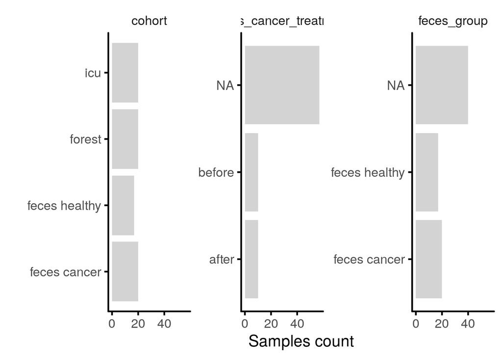

Number of samples grouped by any categrial variable to illustrate balance of the data set

## Denoising

- DADA2 was used to retrieve amplicon sequence variants (ASV) from quality controlled reads (Callahan *et al.*, 2016)
- Singletons were not included.

## Normalization and Filtering

- Hits of denoised sequences were summed up to the genus rank
- Prevalence filtering: All taxa must be abundant at least 0.01% in at least 5% of all samples.
- Centered log ratio was the default normalization

# Results

## Abundance

- Clustermap of normalized abundances was created using Spearman correlation distance

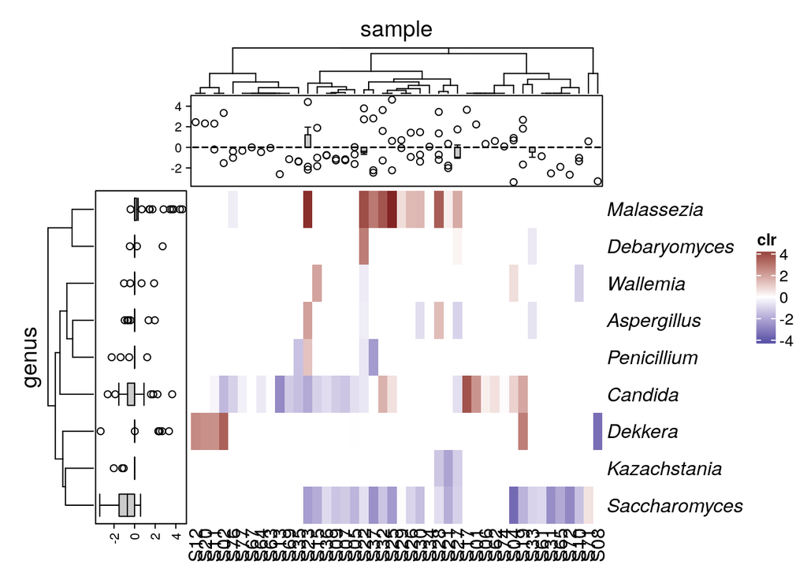

Normalized feature abundances clustered by Spearman correlation

## Alpha diversity

- 9 distinct features were found

## Beta diversity

- Samples were grouped by cohort
- Total counts of non chimeric reads were used to calculate all pairwise Bray-Curtis distances between the samples
- Principal Coordinates Analysis was used for 2D Visualization
- Grouping by cohort was significant (Adonis PERMANOVA, p <1.0*10<sup>-04</sup>)

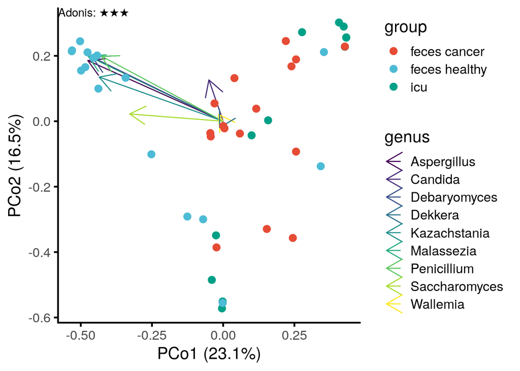

  Ordination Biplot using PCoA and Bray-Curtis metric

## Taxon correlation network

- Pairwise correlations were calculated using SparCC (Friedman and Alm, 2012; Watts *et al.*, 2019)
- Pseudo p values were calculated using 100 bootstraps which 100 iterations each
- Correlations were filtered by significance (p < 0.05)
- P values were adjusted for false discovery rate to yield q values
- Nodes were colored by order of the taxon

[interactive chart not shown]

Significant pairwise correlations

| Feature A | Feature B | coefficient ρ¹ | p value | q value² |
| --- | --- | --- | --- | --- |
| *Malassezia* | *Aspergillus* | 4.4e-01 | 9.9e-03 ★★ | 8e-01 |
| *Saccharomyces* | *Aspergillus* | 2.9e-01 | 4.0e-02 ★ | 1e+00 |
| *Kazachstania* | *Debaryomyces* | -3.8e-01 | 3.0e-02 ★ | 1e+00 |
| *Penicillium* | *Debaryomyces* | -3.7e-01 | 9.9e-03 ★★ | 8e-01 |
| *Malassezia* | *Kazachstania* | 1.8e-01 | 5.0e-02 ★ | 1e+00 |
| *Penicillium* | *Kazachstania* | -3.0e-01 | 2.0e-02 ★ | 1e+00 |
| *Wallemia* | *Kazachstania* | -3.0e-01 | 3.0e-02 ★ | 1e+00 |
| *Penicillium* | *Malassezia* | 1.9e-01 | 4.0e-02 ★ | 1e+00 |
| *Saccharomyces* | *Malassezia* | 5.0e-01 | 9.9e-03 ★★ | 8e-01 |

<sup>1</sup> strength of sparcc correlation [-1; 1]  
<sup>2</sup> FDR adjusted p value

## Statistics

### Two group comparisons

- wilcoxon test

Two groups comparisons

| Grouping | Feature | Paired test | p value | q value | Cliff’s Delta | Log2 FC | higher in |
| --- | --- | --- | --- | --- | --- | --- | --- |
| feces_cancer_treatment | *Candida* | yes | 2.7e-01 | 4.8e-01 | 8.3e-02 | Inf | after |
| feces_cancer_treatment | *Dekkera* | yes | 3.6e-01 | 4.8e-01 | 3.3e-01 | NaN |  |
| feces_cancer_treatment | *Saccharomyces* | yes | 7.2e-01 | 7.2e-01 | 2.2e-01 | -8.1e-02 | before |
| feces_cancer_treatment | *Wallemia* | yes | 2.1e-01 | 4.8e-01 | 1.2e-01 | -Inf | before |

### Multiple groups comparisons

- Kruskal-Wallis rank sum test, FDR adjusted for multiple features
- post hoc test: Dunn’s Test, FDR adjsuted for multiple grouping values
- exact p values can’t be calculated due to ties in zero inflated data

Pre hoc tests

| Variable | Feature | p value | q value |
| --- | --- | --- | --- |
| cohort | *Dekkera* | 2.7e-02 ★ | 8.2e-02 |
| cohort | *Malassezia* | 4.0e-07 ★★★ | 3.6e-06 ★★★ |
| cohort | *Saccharomyces* | 2.3e-03 ★★ | 1.1e-02 ★ |

Post hoc tests

| Variable | Feature | Group A | Group B | higher in | p value | q value | Cliff’s Delta | Log2 FC |
| --- | --- | --- | --- | --- | --- | --- | --- | --- |
| cohort | *Dekkera* | feces cancer | feces healthy | feces cancer | 5.2e-03 ★★ | 1.7e-02 ★ | 2.9e-01 | -Inf |
|  |  | feces cancer | forest | feces cancer | 3.2e-02 ★ | 6.4e-02 | 2.9e-01 | -Inf |
|  |  | feces cancer | icu | feces cancer | 5.8e-03 ★★ | 1.7e-02 ★ | 2.9e-01 | -Inf |
|  | *Malassezia* | feces cancer | feces healthy | feces healthy | 1.4e-06 ★★★ | 4.1e-06 ★★★ | -7.1e-01 | Inf |
|  |  | feces healthy | forest | feces healthy | 3.5e-04 ★★★ | 7.0e-04 ★★★ | 7.1e-01 | -Inf |
|  |  | feces healthy | icu |  | 3.8e-07 ★★★ | 2.3e-06 ★★★ | 7.2e-01 | 0e+00 |
|  | *Saccharomyces* | feces cancer | feces healthy |  | 3.5e-02 ★ | 6.4e-02 | 3.1e-01 | 0e+00 |
|  |  | feces cancer | forest |  | 4.3e-02 ★ | 6.4e-02 | -4.1e-01 | 0e+00 |
|  |  | feces healthy | forest |  | 1.2e-03 ★★ | 3.7e-03 ★★ | -8.2e-01 | 0e+00 |
|  |  | feces healthy | icu |  | 6.4e-04 ★★★ | 3.7e-03 ★★ | -6.0e-01 | 0e+00 |

[interactive chart not shown]

Differentially abundant features

## Machine learning

- Machine learning aims to build a model which predicts a property of the sample based on the features profiled
- 18 models were trained
- Feature selection using ANOVA filtering was performed on 6 models
- Models were evaluated using nested Cross-validation
- Area Under Curve (AUC) of Receiver Operating Characteristic (ROC) was calculated using all resamplings combined for all binary target classes

trained models

| target | model_id | Feature selection | Features used | Classifier | Parameters | AUC¹ | Sens¹ | Spec¹ |
| --- | --- | --- | --- | --- | --- | --- | --- | --- |
| feces_cancer_treatment | 1 | rfe | 4 | rf | mtry=2, ntree=500 | 0.62 | 0.30 | 0.60 |
|  | 2 | sbf | 4 | rf | mtry=2, ntree=500 | 0.70 | 0.50 | 0.70 |
|  | 3 | train | 4 | rf | mtry=2, ntree=500 | 0.62 | 0.50 | 0.60 |
|  | 4 | rfe | 9 | svmRadial | C=64 | 0.60 | 0.30 | 0.90 |
|  | 5 | sbf | 9 | svmRadial | C=128 | 0.70 | 0.40 | 0.80 |
|  | 6 | train | 9 | svmRadial | C=0.5 | 0.35 | 0.20 | 0.50 |
| feces_group | 7 | rfe | 4 | rf | mtry=3, ntree=500 | 0.85 | 0.88 | 0.63 |
|  | 8 | sbf | 9 | rf | mtry=3, ntree=500 | 0.87 | 1.00 | 0.72 |
|  | 9 | train | 9 | rf | mtry=2, ntree=500 | 0.87 | 1.00 | 0.65 |
|  | 10 | rfe | 4 | svmRadial | C=32 | 0.78 | 0.73 | 0.53 |
|  | 11 | sbf | 9 | svmRadial | C=0.5 | 0.57 | 0.65 | 0.50 |
|  | 12 | train | 9 | svmRadial | C=0.5 | 0.70 | 0.45 | 0.63 |
| cohort | 13 | rfe | 4 | rf | mtry=2, ntree=500 | 0.85 | 0.52 | 0.86 |
|  | 14 | sbf | 9 | rf | mtry=2, ntree=500 | 0.82 | 0.54 | 0.87 |
|  | 15 | train | 9 | rf | mtry=2, ntree=500 | 0.84 | 0.52 | 0.87 |
|  | 16 | rfe | 4 | svmRadial | C=1 | 0.82 | 0.45 | 0.82 |
|  | 17 | sbf | 9 | svmRadial | C=64 | 0.83 | 0.51 | 0.86 |
|  | 18 | train | 9 | svmRadial | C=1 | 0.78 | 0.43 | 0.83 |

<sup>1</sup> Best tuned models averaged over all resamples

[interactive chart not shown]

Model performance valuation using ROC

[interactive chart not shown]

Model performance valuation using ROC

### Important features

- Mean Gini decrease was calculated in random forest models 2, 8, 13
- These are potential biomarkers in predicting potential properties of the sample

Most important features (max N=5) to classify sample target

| target | Feature | Gini Importance |
| --- | --- | --- |
| cohort | *Malassezia* | 8.25 |
|  | *Candida* | 8.16 |
|  | *Saccharomyces* | 6.80 |
|  | *Dekkera* | 4.48 |
| feces_cancer_treatment | *Candida* | 1.26 |
|  | *Dekkera* | 1.24 |
|  | *Saccharomyces* | 1.14 |
|  | *Wallemia* | 0.52 |
| feces_group | *Malassezia* | 5.28 |
|  | *Saccharomyces* | 2.73 |
|  | *Candida* | 2.16 |
|  | *Dekkera* | 1.64 |
|  | *Penicillium* | 0.78 |

# References

[1] Bolger, A.M. *et al.* Trimmomatic: A flexible trimmer for illumina sequence data. *Bioinformatics (Oxford, England)* **30,** 2114–20 (2014).

[2] Callahan, B.J. *et al.* DADA2: High-resolution sample inference from illumina amplicon data. *Nature methods* **13,** 581–3 (2016).

[3] Nilsson, R.H. *et al.* The unite database for molecular identification of fungi: Handling dark taxa and parallel taxonomic classifications. *Nucleic acids research* **47,** D259–D264 (2019).

[4] Bolyen, E. *et al.* Reproducible, interactive, scalable and extensible microbiome data science using qiime 2. *Nature biotechnology* **37,** 852–857 (2019).

[5] Friedman, J., and Alm, E.J. Inferring correlation networks from genomic survey data. *PLoS computational biology* **8,** e1002687 (2012).

[6] Watts, S.C. *et al.* FastSpar: Rapid and scalable correlation estimation for compositional data. *Bioinformatics (Oxford, England)* **35,** 1064–1066 (2019).